Please provide your names, last names, and student IDs.

- Aleksandra, Krasicka, 148254
- Bogna, Kilanowska, 148252

# CLASSIFICATION

This exercise consists of three parts. Finish the first part to get a mark of 3.0; the first two parts for 4.0. Complete all three parts to get 5.0.

```python
import common as cm
import numpy as np
import matplotlib.pyplot as plt
import copy
```

# Part 1: Naive Bayes for binary data

1.1 ) Given are the following objects (data) characterized with 4 binary attributes:

```python
data = [
[1, 0, 1, 1],
[0, 1, 0, 0],
[0, 1, 1, 1],
[1, 0, 1, 0],
[1, 0, 0, 1],
[0, 0, 1, 1],
[1, 1, 1, 1],
[1, 0, 0, 1],
[0, 1, 0, 1],
[0, 0, 0, 1],
]
```

1.2) Each object is assigned to a class "0" or "1". The assignements are as follows (cl):

```python
cl = [1, 0, 1, 0, 0, 1, 1, 0, 1, 0]
```

**1.3) When do you think an object is assigned to class "1"?**

```python
def getNaiveBayesProbabilities(obj, data, cl):
    p = [0.0, 0.0]
    # TODo
    s1=1
    s0=1
    for i in range(len(cl)):
        if cl[i]==1:
                s1+=1
        else:
                s0+=1
    p[0]=s0/(len(cl)+1)
    p[1]=s1/(len(cl)+1)
    for i in range(len(obj)):
        s1=0
        s0=0
        l1=0
        l0=0
        for j in range(len(data)):
            if cl[j]==1:
                s1=s1+data[j][i]
                l1+=1
            else:
                s0=s0+data[j][i]
                l0+=1
        s0=float(s0/l0)
        s1=float(s1/l1)
        if obj[i]==0:
            s1=1-s1
            s0=1-s0
        if s1==0:
            s1=0.1
        if s0==0:
            s0=0.1
        p[0]=p[0]*s0
        p[1]=p[1]*s1

    return p
```

1.6) Find objects which give a maximum probability for class "0" and "1".

```python
# TODO

max0=0
max1=0
obj0=[]
obj1=[]
for i in range(2):
    for j in range(2):
        for k in range(2):
            for n in range(2):
                p=getNaiveBayesProbabilities([i,j,k,n], data, cl)
                if p[0]>max0:
                    max0=p[0]
                    obj0=[i,j,k,n]
                if p[1]>max1:
                    max1=p[1]
                    obj1=[i,j,k,n]
print(getNaiveBayesProbabilities(obj0, data, cl))
print(getNaiveBayesProbabilities(obj1, data, cl))
# print(getNaiveBayesProbabilities([], data, cl))
# print(getNaiveBayesProbabilities([], data, cl))
```

```
[0.12567272727272727, 0.017454545454545452]
[0.005236363636363636, 0.15709090909090906]
```

## Part 2: k-NN algorithm

2.1) In common.py, there is defined a Euclidean distance function (cm.getEuclideanDistance(A, B)):

```python
#TEST
print(cm.getEuclideanDistance([0.0, 0.0], [0.0, 1.0]))
print(cm.getEuclideanDistance([0.0, 0.0], [1.0, 1.0]))
```

```
1.0
1.4142135623730951
```

2.2) Get test data set & display:

- DATA: data = matrix n x m, n = the number of objects, m = the number of attributes
- CLASSIFIED : classified objects, [[list of objects (indices) being assigned to the fist class],[... to the second class],...,[... to the last class]]; note that the classes do not impose any preference order
- NOT_CLASSIFIED: list of objects (indices) being not classified

IMPORTANT: plot $\rightarrow$ black squares represent objects that are to be classified.

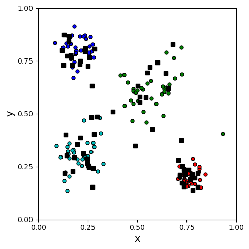

```python
DATA = cm.getTestDataSet()
CLASSIFIED = cm.getTestClassified()
NOT_CLASSIFIED = cm.getTestNotClassified()
cm.displayDataSet(plt, DATA, CLASSIFIED, NOT_CLASSIFIED) #plt = plot package; see the imports above

### CLASS 1 = BLUE
### CLASS 2 = GREEN
### CLASS 3 = RED
### CLASS 4 = CYAN
```

2.3) k-NN implementation: Complete the below function. Use the "non-weighted" of k-NN.

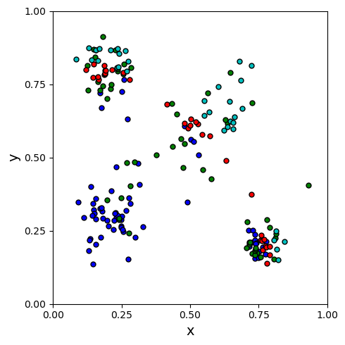

```python
def tabelka(tab,clas,bez):
    tab2=copy.deepcopy(tab)
    for i in range(len(clas)):
        for j in range(len(clas[i])):
            tab2[clas[i][j]].append(i)
    for j in range(len(bez)):
            del tab2[bez[j]-j]
    return(tab2)

def sortu(a,tab):
    t=0
    tab2=copy.deepcopy(tab)
    for i in range(len(tab2)):
        x=cm.getEuclideanDistance(a,tab2[i][::2])
        t=i
        for j in range(i,len(tab2)):
            if cm.getEuclideanDistance(a,tab2[j][::2])<x:
                tab2[j],tab2[t]=tab2[t],tab2[j]
                t=j
    #print(tab2)
    return(tab2)
def doKNN(K, DATA, CLASSIFIED, NOT_CLASSIFIED):
    ### COPY INPUT CLASSIFIED OBJECTS
    ### WHEN CLASSIFYING "NOT_CLASSIFIED" OBJECTS, UPDATE THE CL, i.e., ADD RESPECTIVE INDICES
    CL = copy.deepcopy(CLASSIFIED)
    ### For each index in NOT_CLASSIFIED, store here its corresponding (computed) class (in this exercise = 0, 1, or 2)
    UPDATE = []
    tab=tabelka(DATA,CLASSIFIED,NOT_CLASSIFIED)
    for IDX in range(len(NOT_CLASSIFIED)):
        tab=sortu(DATA[NOT_CLASSIFIED[IDX]],tab)
        clas=[]
        s=[0 for i in range(len(CLASSIFIED))]
        for i in range(K):
            clas.append(tab[i][2])
            s[tab[i][2]]+=1
        clas.sort()
        #print(clas)
        #print(s)
        x=max(s)
        y=0
        for i in range(len(s)):
            if s[i]==x:
                y+=1
        if y==1:
            CL[s.index(x)].append(NOT_CLASSIFIED[IDX])
            UPDATE.append(NOT_CLASSIFIED[IDX])
        #print(clas)
    ################
    return CL

#DISPLAY CLASSIFIED DATA
#sortu([0.0,0.0],DATA, CLASSIFIED)
#print(NOT_CLASSIFIED)
#cm.displayDataSet(plt, DATA, CLASSIFIED, NOT_CLASSIFIED)
NEW_CLASSIFIED = doKNN(2, DATA, CLASSIFIED, NOT_CLASSIFIED)
cm.displayDataSet(plt, DATA, NEW_CLASSIFIED)
```

# Part 3 - performance evaluation

3.1) You are asked to evaluate the performance of k-NN (weighted variant) for K = 3. Firstly, run the below piece of code and analyze the data. **Question: Which class do you think is the most difficult/easiest to describe/characterize?**

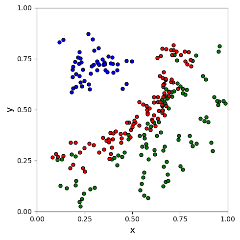

```python
DATA_P3 = cm.getTest2DataSet()
CLASSIFIED_P3 = cm.getTest2Classified()
cm.displayDataSet(plt, DATA_P3, CLASSIFIED_P3)

### CLASS 1 = BLUE
### CLASS 2 = GREEN
### CLASS 3 = RED
#class 1 is easiest coz all elements that x<0.5 and y>0.5 are in this group
#class 2 is the most difficult coz some of the elements are mixed with elements in the class 3 and class 2 has the biggest range of x and y that are included in it (the biggest defrence between the smalest and the biggest in both x,y)
```

3.2) To evaluate the performance of k-NN, you can check how well it predicts classes for new (not known previously) objects. For this reason, assume that you "do not know" the true class assignments for some random subset of objects from the data set. Firstly, you can generate some permutation of indices from 0 to 249 (one per object):

```python
idxs = [i for i in range(250)]
np.random.shuffle(idxs)
```

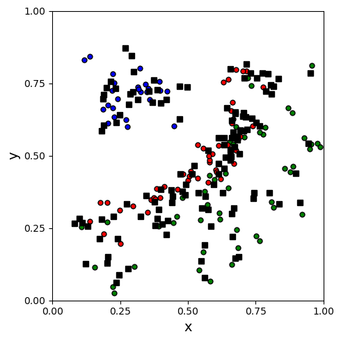

```python
CLASSIFIED_TRAIN = [[], [], []]
NOT_CLASSIFIED_TEST = []
LIM = int(len(DATA_P3) * 0.5)
for i in range(LIM):
    if idxs[i] < 50: CLASSIFIED_TRAIN[0].append(idxs[i])
    elif idxs[i] < 150: CLASSIFIED_TRAIN[1].append(idxs[i])
    else: CLASSIFIED_TRAIN[2].append(idxs[i])
for i in range(LIM, 250):
    NOT_CLASSIFIED_TEST.append(idxs[i])
cm.displayDataSet(plt, DATA_P3, CLASSIFIED_TRAIN, NOT_CLASSIFIED_TEST)
```

3.3) Evaluate the performance of the weighted variant of k-NN for K = 3 and CLASSIFIED_TRAIN, NOT_CLASSIFIED_TEST data sets.

- for each class, compute how many times an object has been correctly/incorrectly classified. E.g., if 10 objects are associated with the first class "BLUE" but k-NN classified correctly only 4 of them, the result is 4 (or 6 in case of incorrect assignments stat);
- for each class, compute recall (number of correct assignments / total number of expected assignments, e.g., if 10 objects are associated with the first class "BLUE" but k-NN classified correctly only 4 of them, recall for the first class is 40%);

**Question: Which class got the best/the worst recall. Why? OPTIONAL: YOU CAN VERIFY THE PERFORMANCE FOR K = 1, 3, 5, 7** You can use cm.displayCompareDataSet(plt, DATA_P3, CLASSIFIED_P3, CL) to check (display) which solutions were classified incorrectly. These are marked with squares. The background of these squares is appropriately selected according to the true (expected) assignment.

```python
### CLASS 1 = BLUE
### CLASS 2 = GREEN
### CLASS 3 = RED

for K in [1,3,5,7]:
    CL = doKNN(K, DATA_P3, CLASSIFIED_TRAIN, NOT_CLASSIFIED_TEST)
    print(K)
    CORRECTLY = [0,0,0]
    INCORRECTLY = [0,0,0]
    RECALL = [0,0,0]

    #TODO

    ### PRINT STATS
    print(CORRECTLY)
    print(INCORRECTLY)
    print(RECALL)
    ### DISPLAY
    cm.displayCompareDataSet(plt, DATA_P3, CLASSIFIED_P3, CL)
```

[output not shown]